# Анализ рынка видеоигр

### Цель исследования:

- Выявление закономерностей, определяющих успех видеоигры.
- Проверка гипотезы: Средние пользовательские рейтинги платформ Xbox One и PC одинаковые.
- Проверка гипотезы: Средние пользовательские рейтинги жанров Action и Sports разные.
- Определить портрет пользователя каждого региона.

### Содержание:

- Загрузка данных
- Предобработка данных
- Исследовательский анализ данных
  - Количество игр по годам
  - Продажи по платформам
  - Актуальный период
  - Анализ продаж
  - Влияние отзывов игроков и критиков
  - Распределение по жанрам
- Портреты пользователей по регионам
  - Самые популярные платформы и жанры
  - Влияние рейтинга ESRB на продажи
- Проверка Гипотез
  - Рейтинги XOne и PC
  - Рейтинги Action и Sports
- Выводы

## Загрузка данных и знакомство с данными

```python
# импорт библиотек
import pandas as pd
import numpy as np
import matplotlib.pyplot as plt
import seaborn as sns
from scipy import stats as st
from math import factorial
import warnings
warnings.filterwarnings(action='ignore')
```

```python
games = pd.read_csv('/datasets/games.csv')
```

```python
display(games.head(10))
games.info()
```

|  | Name | Platform | Year_of_Release | Genre | NA_sales | EU_sales | JP_sales | Other_sales | Critic_Score | User_Score | Rating |
| --- | --- | --- | --- | --- | --- | --- | --- | --- | --- | --- | --- |
| 0 | Wii Sports | Wii | 2006.0 | Sports | 41.36 | 28.96 | 3.77 | 8.45 | 76.0 | 8 | E |
| 1 | Super Mario Bros. | NES | 1985.0 | Platform | 29.08 | 3.58 | 6.81 | 0.77 | NaN | NaN | NaN |
| 2 | Mario Kart Wii | Wii | 2008.0 | Racing | 15.68 | 12.76 | 3.79 | 3.29 | 82.0 | 8.3 | E |
| 3 | Wii Sports Resort | Wii | 2009.0 | Sports | 15.61 | 10.93 | 3.28 | 2.95 | 80.0 | 8 | E |
| 4 | Pokemon Red/Pokemon Blue | GB | 1996.0 | Role-Playing | 11.27 | 8.89 | 10.22 | 1.00 | NaN | NaN | NaN |
| 5 | Tetris | GB | 1989.0 | Puzzle | 23.20 | 2.26 | 4.22 | 0.58 | NaN | NaN | NaN |
| 6 | New Super Mario Bros. | DS | 2006.0 | Platform | 11.28 | 9.14 | 6.50 | 2.88 | 89.0 | 8.5 | E |
| 7 | Wii Play | Wii | 2006.0 | Misc | 13.96 | 9.18 | 2.93 | 2.84 | 58.0 | 6.6 | E |
| 8 | New Super Mario Bros. Wii | Wii | 2009.0 | Platform | 14.44 | 6.94 | 4.70 | 2.24 | 87.0 | 8.4 | E |
| 9 | Duck Hunt | NES | 1984.0 | Shooter | 26.93 | 0.63 | 0.28 | 0.47 | NaN | NaN | NaN |

```
<class 'pandas.core.frame.DataFrame'>
RangeIndex: 16715 entries, 0 to 16714
Data columns (total 11 columns):
 #   Column           Non-Null Count  Dtype
---  ------           --------------  -----
 0   Name             16713 non-null  object
 1   Platform         16715 non-null  object
 2   Year_of_Release  16446 non-null  float64
 3   Genre            16713 non-null  object
 4   NA_sales         16715 non-null  float64
 5   EU_sales         16715 non-null  float64
 6   JP_sales         16715 non-null  float64
 7   Other_sales      16715 non-null  float64
 8   Critic_Score     8137 non-null   float64
 9   User_Score       10014 non-null  object
 10  Rating           9949 non-null   object
dtypes: float64(6), object(5)
memory usage: 1.4+ MB
```

```python
#Проверяю пропуски на подозрительных столбцах
print('Год релиза - пропусков:')
display(games['Year_of_Release'].isna().sum())
print('Оценка критиков - пропусков:')
display(games['Critic_Score'].isna().sum())
print('Оценка игроков - пропусков:')
display(games['User_Score'].isna().sum())
print('Возрастной рейтинг - пропусков:')
display(games['Rating'].isna().sum())
```

```
Год релиза - пропусков:
```

```
269
```

```
Оценка критиков - пропусков:
```

```
8578
```

```
Оценка игроков - пропусков:
```

```
6701
```

```
Возрастной рейтинг - пропусков:
```

```
6766
```

Данные требуют корректировки:

- Тип данных неверный в некоторых столбцах. Возможно, это скрытые пропуски.
- Пропусков в столбце с годом релиза немного, их можно удалить. В столбцах с оценками и рейтингом пропусков очень много, их трогать не буду. Их наличие вероятно связанно с тем, что многие игры выпущенны до появления системы возрастной оценки (Ее создали во второй половине девяностых под воздействием общественности, обеспокоенной влиянием жестоких игр), а оценок критиков и пользователей нет для малоизвестных игр или они не выгрузились с агрегатора.
- Нужно привести названия столбцов в более удобный вид.
- Требуется проверить данные на дубликаты

## Предобработка данных

Исправляю названия столбцов

```python
games.columns = games.columns.str.lower()
```

Проверка на явные дубликаты

```python
display(games.loc[games.duplicated(subset=['name', 'platform', 'year_of_release'])])
```

|  | name | platform | year_of_release | genre | na_sales | eu_sales | jp_sales | other_sales | critic_score | user_score | rating |
| --- | --- | --- | --- | --- | --- | --- | --- | --- | --- | --- | --- |
| 14244 | NaN | GEN | 1993.0 | NaN | 0.0 | 0.00 | 0.03 | 0.0 | NaN | NaN | NaN |
| 16230 | Madden NFL 13 | PS3 | 2012.0 | Sports | 0.0 | 0.01 | 0.00 | 0.0 | 83.0 | 5.5 | E |

```python
games = games.drop_duplicates(subset=['name', 'platform', 'year_of_release'], keep='first')
display(games.loc[games.duplicated(subset=['name', 'platform', 'year_of_release'])])
```

|  | name | platform | year_of_release | genre | na_sales | eu_sales | jp_sales | other_sales | critic_score | user_score | rating |
| --- | --- | --- | --- | --- | --- | --- | --- | --- | --- | --- | --- |

Год релиза - удаляю пропуски и привожу к нужному типу

```python
temp = games.copy() # создаем копию датасета до преобразования
len(temp)
```

```
16713
```

```python
games = games.dropna(subset=['year_of_release'])
games['year_of_release'] = games['year_of_release'].astype('int')
#display(games['year_of_release'].unique())
```

```python
a, b = len(temp), len(games)
print(a, b, round((a-b)/a*100, 2))
```

```
16713 16444 1.61
```

Проверяю на скрытые пропуски и дубликаты

```python
print('genre:')
display(games['genre'].unique())
print('platform:')
display(games['platform'].unique())
print('critic_score:')
display(games['critic_score'].unique())
print('user_score:')
display(games['user_score'].unique())
print('rating:')
display(games['rating'].unique())

#display(games['critic_score'].value_counts())
```

```
genre:
```

```
array(['Sports', 'Platform', 'Racing', 'Role-Playing', 'Puzzle', 'Misc',
       'Shooter', 'Simulation', 'Action', 'Fighting', 'Adventure',
       'Strategy', nan], dtype=object)
```

```
platform:
```

```
array(['Wii', 'NES', 'GB', 'DS', 'X360', 'PS3', 'PS2', 'SNES', 'GBA',
       'PS4', '3DS', 'N64', 'PS', 'XB', 'PC', '2600', 'PSP', 'XOne',
       'WiiU', 'GC', 'GEN', 'DC', 'PSV', 'SAT', 'SCD', 'WS', 'NG', 'TG16',
       '3DO', 'GG', 'PCFX'], dtype=object)
```

```
critic_score:
```

```
array([76., nan, 82., 80., 89., 58., 87., 91., 61., 97., 95., 77., 88.,
       83., 94., 93., 85., 86., 98., 96., 90., 84., 73., 74., 78., 92.,
       71., 72., 68., 62., 49., 67., 81., 66., 56., 79., 70., 59., 64.,
       75., 60., 63., 69., 50., 25., 42., 44., 55., 48., 57., 29., 47.,
       65., 54., 20., 53., 37., 38., 33., 52., 30., 32., 43., 45., 51.,
       40., 46., 39., 34., 41., 36., 31., 27., 35., 26., 19., 28., 23.,
       24., 21., 17., 13.])
```

```
user_score:
```

```
array(['8', nan, '8.3', '8.5', '6.6', '8.4', '8.6', '7.7', '6.3', '7.4',
       '8.2', '9', '7.9', '8.1', '8.7', '7.1', '3.4', '5.3', '4.8', '3.2',
       '8.9', '6.4', '7.8', '7.5', '2.6', '7.2', '9.2', '7', '7.3', '4.3',
       '7.6', '5.7', '5', '9.1', '6.5', 'tbd', '8.8', '6.9', '9.4', '6.8',
       '6.1', '6.7', '5.4', '4', '4.9', '4.5', '9.3', '6.2', '4.2', '6',
       '3.7', '4.1', '5.8', '5.6', '5.5', '4.4', '4.6', '5.9', '3.9',
       '3.1', '2.9', '5.2', '3.3', '4.7', '5.1', '3.5', '2.5', '1.9', '3',
       '2.7', '2.2', '2', '9.5', '2.1', '3.6', '2.8', '1.8', '3.8', '0',
       '1.6', '9.6', '2.4', '1.7', '1.1', '0.3', '1.5', '0.7', '1.2',
       '2.3', '0.5', '1.3', '0.2', '0.6', '1.4', '0.9', '1', '9.7'],
      dtype=object)
```

```
rating:
```

```
array(['E', nan, 'M', 'T', 'E10+', 'K-A', 'AO', 'EC', 'RP'], dtype=object)
```

- Оценки критиков имеют слишком много пропусков - решено оставить как есть. Это может быть связанно с тем, что критики выпускают рецензии на малоизвестные и низкобюджетные игры так как это им не выгодно.
- Оценки пользователей имеют скрытый текстовы пропуск - его удалим чтобы он не мешал при анализе данных и построении графиков. По этой же причине приведу рейтинг пользователей в численный формат.
- Рейтинг игр:
  - Имеются скрытые дубликаты - названия возрастных цензов, которые использовались раньше. Это EC и K-A (сейчас все они E)
  - Имеются скрытые пропуски - RP означает что рейтинга у игры на данный момент нет.
  - Очень много пропусков, однако это объясняется тем, что ESRB основанна в середине 90-х, и все игры до этого момента не имеют ее оценок, ко всему прочему это Американская организация, и она может не оценивать игры, которые, к примеру, предназначенны только для рынка Японии. Поэтому пропуски оставляем.

```python
temp = games.copy() # создаем копию датасета до преобразования
len(temp)
```

```
16444
```

```python
# Удаляем пропуски у жанров
games = games.dropna(subset=['genre'])

#Удаляю скрытый пропуск и меняю тип данных в оценках игроков
games.user_score.replace('tbd', np.nan, inplace=True)
games['user_score'] = games['user_score'].astype('float')
```

```python
a, b = len(temp), len(games)
print(a, b, round((a-b)/a*100, 2))
```

```
16444 16443 0.01
```

Проверяю пропуски в названии игр

```python
display(games[games['name'].isna()])
games = games.dropna(subset=['name'])
```

|  | name | platform | year_of_release | genre | na_sales | eu_sales | jp_sales | other_sales | critic_score | user_score | rating |
| --- | --- | --- | --- | --- | --- | --- | --- | --- | --- | --- | --- |

Теперь посчитаю суммарные продажи во всех регионах

```python
games['total_sales'] = games['na_sales'] + games['eu_sales'] + games['jp_sales'] + games['other_sales']
games.head(3)
```

|  | name | platform | year_of_release | genre | na_sales | eu_sales | jp_sales | other_sales | critic_score | user_score | rating | total_sales |
| --- | --- | --- | --- | --- | --- | --- | --- | --- | --- | --- | --- | --- |
| 0 | Wii Sports | Wii | 2006 | Sports | 41.36 | 28.96 | 3.77 | 8.45 | 76.0 | 8.0 | E | 82.54 |
| 1 | Super Mario Bros. | NES | 1985 | Platform | 29.08 | 3.58 | 6.81 | 0.77 | NaN | NaN | NaN | 40.24 |
| 2 | Mario Kart Wii | Wii | 2008 | Racing | 15.68 | 12.76 | 3.79 | 3.29 | 82.0 | 8.3 | E | 35.52 |

```python
# Исправляем дубликаты и пропуски в рейтинге
games.loc[games['rating'] == 'EC', 'rating'] = 'E'
games.loc[games['rating'] == 'K-A', 'rating'] = 'E'
games.loc[games['rating'] == 'RP', 'rating'] = 'no_rating'
games['rating'] = games['rating'].fillna('no_rating')
```

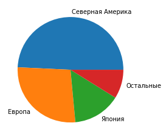

```python
sales = games.agg('sum')[['na_sales', 'eu_sales', 'jp_sales', 'other_sales']]
labels_sales = ['Северная Америка','Европа','Япония','Остальные']
fig1, ax = plt.subplots()
ax.pie(sales, labels=labels_sales)
plt.show()
```

```python
# Посмотрим, что осталось
temp = games.copy()
list_c = ['name', 'platform', 'year_of_release', 'genre', 'critic_score', 'user_score', 'rating']
print(temp.info())
for col_l in list_c:
  print('-'* 25)
  print(col_l, temp[col_l].sort_values().unique())
  print(col_l,': кол-во NaN',temp[col_l].isna().sum(),
        ', процент NaN', round(temp[col_l].isna().mean()*100,2),'%')
```

```
<class 'pandas.core.frame.DataFrame'>
Int64Index: 16443 entries, 0 to 16714
Data columns (total 12 columns):
 #   Column           Non-Null Count  Dtype
---  ------           --------------  -----
 0   name             16443 non-null  object
 1   platform         16443 non-null  object
 2   year_of_release  16443 non-null  int64
 3   genre            16443 non-null  object
 4   na_sales         16443 non-null  float64
 5   eu_sales         16443 non-null  float64
 6   jp_sales         16443 non-null  float64
 7   other_sales      16443 non-null  float64
 8   critic_score     7982 non-null   float64
 9   user_score       7462 non-null   float64
 10  rating           16443 non-null  object
 11  total_sales      16443 non-null  float64
dtypes: float64(7), int64(1), object(4)
memory usage: 1.6+ MB
None
-------------------------
name [' Beyblade Burst' ' Fire Emblem Fates' " Frozen: Olaf's Quest" ...
 'uDraw Studio' 'uDraw Studio: Instant Artist'
 '¡Shin Chan Flipa en colores!']
name : кол-во NaN 0 , процент NaN 0.0 %
-------------------------
platform ['2600' '3DO' '3DS' 'DC' 'DS' 'GB' 'GBA' 'GC' 'GEN' 'GG' 'N64' 'NES' 'NG'
 'PC' 'PCFX' 'PS' 'PS2' 'PS3' 'PS4' 'PSP' 'PSV' 'SAT' 'SCD' 'SNES' 'TG16'
 'WS' 'Wii' 'WiiU' 'X360' 'XB' 'XOne']
platform : кол-во NaN 0 , процент NaN 0.0 %
-------------------------
year_of_release [1980 1981 1982 1983 1984 1985 1986 1987 1988 1989 1990 1991 1992 1993
 1994 1995 1996 1997 1998 1999 2000 2001 2002 2003 2004 2005 2006 2007
 2008 2009 2010 2011 2012 2013 2014 2015 2016]
year_of_release : кол-во NaN 0 , процент NaN 0.0 %
-------------------------
genre ['Action' 'Adventure' 'Fighting' 'Misc' 'Platform' 'Puzzle' 'Racing'
 'Role-Playing' 'Shooter' 'Simulation' 'Sports' 'Strategy']
genre : кол-во NaN 0 , процент NaN 0.0 %
-------------------------
critic_score [13. 17. 19. 20. 21. 23. 24. 25. 26. 27. 28. 29. 30. 31. 32. 33. 34. 35.
 36. 37. 38. 39. 40. 41. 42. 43. 44. 45. 46. 47. 48. 49. 50. 51. 52. 53.
 54. 55. 56. 57. 58. 59. 60. 61. 62. 63. 64. 65. 66. 67. 68. 69. 70. 71.
 72. 73. 74. 75. 76. 77. 78. 79. 80. 81. 82. 83. 84. 85. 86. 87. 88. 89.
 90. 91. 92. 93. 94. 95. 96. 97. 98. nan]
critic_score : кол-во NaN 8461 , процент NaN 51.46 %
-------------------------
user_score [0.  0.2 0.3 0.5 0.6 0.7 0.9 1.  1.1 1.2 1.3 1.4 1.5 1.6 1.7 1.8 1.9 2.
 2.1 2.2 2.3 2.4 2.5 2.6 2.7 2.8 2.9 3.  3.1 3.2 3.3 3.4 3.5 3.6 3.7 3.8
 3.9 4.  4.1 4.2 4.3 4.4 4.5 4.6 4.7 4.8 4.9 5.  5.1 5.2 5.3 5.4 5.5 5.6
 5.7 5.8 5.9 6.  6.1 6.2 6.3 6.4 6.5 6.6 6.7 6.8 6.9 7.  7.1 7.2 7.3 7.4
 7.5 7.6 7.7 7.8 7.9 8.  8.1 8.2 8.3 8.4 8.5 8.6 8.7 8.8 8.9 9.  9.1 9.2
 9.3 9.4 9.5 9.6 9.7 nan]
user_score : кол-во NaN 8981 , процент NaN 54.62 %
-------------------------
rating ['AO' 'E' 'E10+' 'M' 'T' 'no_rating']
rating : кол-во NaN 0 , процент NaN 0.0 %
```

## Исследовательский анализ данных

### Количество игр по годам

```python
games_per_year = games.pivot_table(index = 'platform', columns = 'year_of_release', values = 'name', aggfunc='count', fill_value=0).reset_index()
display(games_per_year)
```

| year_of_release | platform | 1980 | 1981 | 1982 | 1983 | 1984 | 1985 | 1986 | 1987 | 1988 | ... | 2007 | 2008 | 2009 | 2010 | 2011 | 2012 | 2013 | 2014 | 2015 | 2016 |
| --- | --- | --- | --- | --- | --- | --- | --- | --- | --- | --- | --- | --- | --- | --- | --- | --- | --- | --- | --- | --- | --- |
| 0 | 2600 | 9 | 46 | 36 | 11 | 1 | 1 | 2 | 6 | 2 | ... | 0 | 0 | 0 | 0 | 0 | 0 | 0 | 0 | 0 | 0 |
| 1 | 3DO | 0 | 0 | 0 | 0 | 0 | 0 | 0 | 0 | 0 | ... | 0 | 0 | 0 | 0 | 0 | 0 | 0 | 0 | 0 | 0 |
| 2 | 3DS | 0 | 0 | 0 | 0 | 0 | 0 | 0 | 0 | 0 | ... | 0 | 0 | 0 | 0 | 116 | 93 | 91 | 80 | 86 | 46 |
| 3 | DC | 0 | 0 | 0 | 0 | 0 | 0 | 0 | 0 | 0 | ... | 1 | 1 | 0 | 0 | 0 | 0 | 0 | 0 | 0 | 0 |
| 4 | DS | 0 | 0 | 0 | 0 | 0 | 1 | 0 | 0 | 0 | ... | 376 | 492 | 403 | 323 | 153 | 23 | 8 | 0 | 0 | 0 |
| 5 | GB | 0 | 0 | 0 | 0 | 0 | 0 | 0 | 0 | 1 | ... | 0 | 0 | 0 | 0 | 0 | 0 | 0 | 0 | 0 | 0 |
| 6 | GBA | 0 | 0 | 0 | 0 | 0 | 0 | 0 | 0 | 0 | ... | 6 | 0 | 0 | 0 | 0 | 0 | 0 | 0 | 0 | 0 |
| 7 | GC | 0 | 0 | 0 | 0 | 0 | 0 | 0 | 0 | 0 | ... | 4 | 0 | 0 | 0 | 0 | 0 | 0 | 0 | 0 | 0 |
| 8 | GEN | 0 | 0 | 0 | 0 | 0 | 0 | 0 | 0 | 0 | ... | 0 | 0 | 0 | 0 | 0 | 0 | 0 | 0 | 0 | 0 |
| 9 | GG | 0 | 0 | 0 | 0 | 0 | 0 | 0 | 0 | 0 | ... | 0 | 0 | 0 | 0 | 0 | 0 | 0 | 0 | 0 | 0 |
| 10 | N64 | 0 | 0 | 0 | 0 | 0 | 0 | 0 | 0 | 0 | ... | 0 | 0 | 0 | 0 | 0 | 0 | 0 | 0 | 0 | 0 |
| 11 | NES | 0 | 0 | 0 | 6 | 13 | 11 | 19 | 10 | 11 | ... | 0 | 0 | 0 | 0 | 0 | 0 | 0 | 0 | 0 | 0 |
| 12 | NG | 0 | 0 | 0 | 0 | 0 | 0 | 0 | 0 | 0 | ... | 0 | 0 | 0 | 0 | 0 | 0 | 0 | 0 | 0 | 0 |
| 13 | PC | 0 | 0 | 0 | 0 | 0 | 1 | 0 | 0 | 1 | ... | 62 | 76 | 107 | 90 | 139 | 61 | 38 | 47 | 50 | 54 |
| 14 | PCFX | 0 | 0 | 0 | 0 | 0 | 0 | 0 | 0 | 0 | ... | 0 | 0 | 0 | 0 | 0 | 0 | 0 | 0 | 0 | 0 |
| 15 | PS | 0 | 0 | 0 | 0 | 0 | 0 | 0 | 0 | 0 | ... | 0 | 0 | 0 | 0 | 0 | 0 | 0 | 0 | 0 | 0 |
| 16 | PS2 | 0 | 0 | 0 | 0 | 0 | 0 | 0 | 0 | 0 | ... | 214 | 191 | 96 | 38 | 7 | 0 | 0 | 0 | 0 | 0 |
| 17 | PS3 | 0 | 0 | 0 | 0 | 0 | 0 | 0 | 0 | 0 | ... | 90 | 138 | 162 | 181 | 215 | 147 | 126 | 108 | 73 | 38 |
| 18 | PS4 | 0 | 0 | 0 | 0 | 0 | 0 | 0 | 0 | 0 | ... | 0 | 0 | 0 | 0 | 0 | 0 | 16 | 75 | 137 | 164 |
| 19 | PSP | 0 | 0 | 0 | 0 | 0 | 0 | 0 | 0 | 0 | ... | 133 | 100 | 161 | 188 | 139 | 106 | 54 | 10 | 3 | 0 |
| 20 | PSV | 0 | 0 | 0 | 0 | 0 | 0 | 0 | 0 | 0 | ... | 0 | 0 | 0 | 0 | 18 | 53 | 63 | 100 | 110 | 85 |
| 21 | SAT | 0 | 0 | 0 | 0 | 0 | 0 | 0 | 0 | 0 | ... | 0 | 0 | 0 | 0 | 0 | 0 | 0 | 0 | 0 | 0 |
| 22 | SCD | 0 | 0 | 0 | 0 | 0 | 0 | 0 | 0 | 0 | ... | 0 | 0 | 0 | 0 | 0 | 0 | 0 | 0 | 0 | 0 |
| 23 | SNES | 0 | 0 | 0 | 0 | 0 | 0 | 0 | 0 | 0 | ... | 0 | 0 | 0 | 0 | 0 | 0 | 0 | 0 | 0 | 0 |
| 24 | TG16 | 0 | 0 | 0 | 0 | 0 | 0 | 0 | 0 | 0 | ... | 0 | 0 | 0 | 0 | 0 | 0 | 0 | 0 | 0 | 0 |
| 25 | WS | 0 | 0 | 0 | 0 | 0 | 0 | 0 | 0 | 0 | ... | 0 | 0 | 0 | 0 | 0 | 0 | 0 | 0 | 0 | 0 |
| 26 | Wii | 0 | 0 | 0 | 0 | 0 | 0 | 0 | 0 | 0 | ... | 185 | 282 | 325 | 253 | 143 | 31 | 12 | 6 | 4 | 1 |
| 27 | WiiU | 0 | 0 | 0 | 0 | 0 | 0 | 0 | 0 | 0 | ... | 0 | 0 | 0 | 0 | 0 | 32 | 42 | 31 | 28 | 14 |
| 28 | X360 | 0 | 0 | 0 | 0 | 0 | 0 | 0 | 0 | 0 | ... | 123 | 146 | 172 | 182 | 206 | 106 | 75 | 63 | 35 | 13 |
| 29 | XB | 0 | 0 | 0 | 0 | 0 | 0 | 0 | 0 | 0 | ... | 3 | 1 | 0 | 0 | 0 | 0 | 0 | 0 | 0 | 0 |
| 30 | XOne | 0 | 0 | 0 | 0 | 0 | 0 | 0 | 0 | 0 | ... | 0 | 0 | 0 | 0 | 0 | 0 | 19 | 61 | 80 | 87 |

31 rows × 38 columns

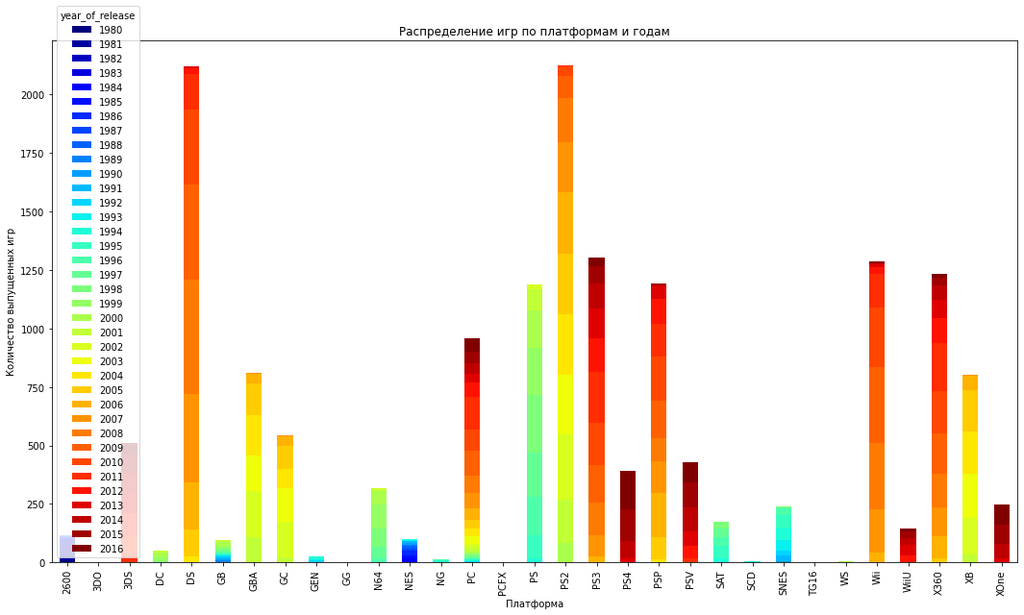

```python
#jupyter плохо отображает широкие таблицы, построю график

games_per_year2 = games.pivot_table(index='platform',columns='year_of_release',values='name',aggfunc='count')

fig, ax = plt.subplots(figsize=(18, 10))

games_per_year2.plot(kind='bar',stacked=True, ax=ax, cmap="jet")
ax.set_xlabel('Платформа')
ax.set_ylabel('Количество выпущенных игр')
ax.set_title('Распределение игр по платформам и годам')

plt.show()
```

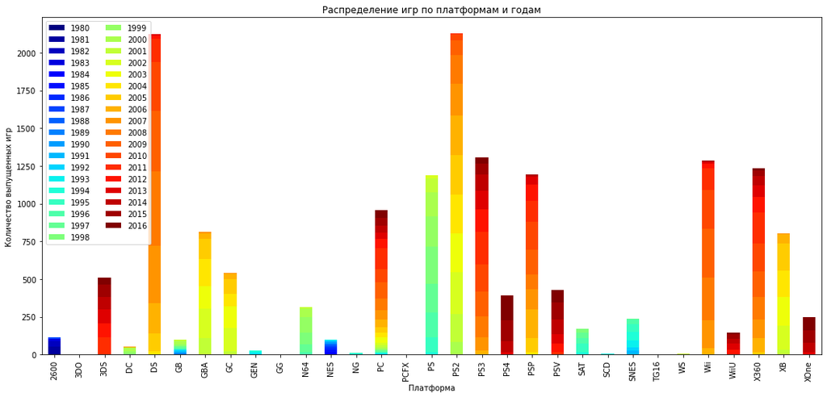

```python
games_per_year2 = games.pivot_table(index='platform',columns='year_of_release',
                                    values='name',aggfunc='count')
fig, ax = plt.subplots(figsize=(18, 8))

games_per_year2.plot(kind='bar',stacked=True, ax=ax, cmap="jet")
ax.set_xlabel('Платформа')
ax.set_ylabel('Количество выпущенных игр')
ax.set_title('Распределение игр по платформам и годам')
plt.legend(bbox_to_anchor=[0, 1], loc='upper left', ncol=2)
plt.show()
```

На графике хорошо видно какие платформы сильно устарели и неинтересны нам. А самые популярные у игроделов платформы это PS2 и DS. На графике хорошо можно увидеть какие платформы только наращивают популярность (бордового цвета в них больше чем других цветов), а какие уже давно устарели или начали устаревать (темно-красные цвета в малом количестве или отсутствуют). Есть тут одна особенная платформа - ПК. Видно что ее пик был в 2011 году, однако остальные сегменты не уменьшаются. Это означает, что данная платформа не теряет своей актуальности многие годы. А всплеск 2011-го года может быть связан с большими продажами игр в целом в этот год. Чтобы это проверить, попробуем повернуть график.

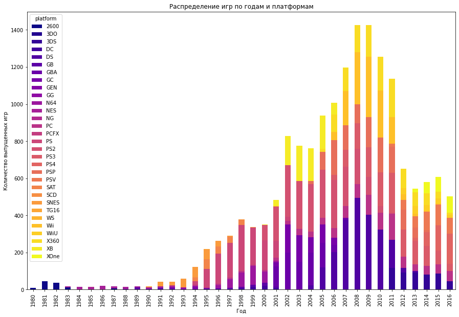

```python
fig, ax = plt.subplots(figsize=(15, 10))

games_per_year2.T.plot(kind='bar',stacked=True, ax=ax, cmap="plasma")
ax.set_xlabel('Год')
ax.set_ylabel('Количество выпущенных игр')
ax.set_title('Распределение игр по годам и платформам')

plt.show()
```

Больше всего игр выходило с 2002 года по 2012, по всей видимости на актуальные консоли восьмого поколения игры начали делать не так давно, поэтому и их количество резко падает. График подтверждает гипотезу каксаемо актуальности PC. Спад продаж в 2016 году можно объяснить неполнотой данных.

### Продажи по платформам

```python
platform_pivot = games.pivot_table(index='platform', values='total_sales', aggfunc='sum').sort_values('total_sales',ascending=False)
display(platform_pivot.head(8))
```

| platform | total_sales |
| --- | --- |
| PS2 | 1233.56 |
| X360 | 961.24 |
| PS3 | 931.33 |
| Wii | 891.18 |
| DS | 802.78 |
| PS | 727.58 |
| PS4 | 314.14 |
| GBA | 312.88 |

```python
data_sum_sales = games.pivot_table(index = 'year_of_release', columns = 'platform', values = 'total_sales', aggfunc = 'sum').fillna(0)[['PS2', 'X360','PS3','Wii', 'DS', 'PS4', 'PS','XB']].reset_index()
data_sum_sales = data_sum_sales.query('year_of_release > 1993')
display(data_sum_sales)
```

| platform | year_of_release | PS2 | X360 | PS3 | Wii | DS | PS4 | PS | XB |
| --- | --- | --- | --- | --- | --- | --- | --- | --- | --- |
| 14 | 1994 | 0.00 | 0.00 | 0.00 | 0.00 | 0.00 | 0.00 | 6.03 | 0.00 |
| 15 | 1995 | 0.00 | 0.00 | 0.00 | 0.00 | 0.00 | 0.00 | 35.96 | 0.00 |
| 16 | 1996 | 0.00 | 0.00 | 0.00 | 0.00 | 0.00 | 0.00 | 94.70 | 0.00 |
| 17 | 1997 | 0.00 | 0.00 | 0.00 | 0.00 | 0.00 | 0.00 | 136.17 | 0.00 |
| 18 | 1998 | 0.00 | 0.00 | 0.00 | 0.00 | 0.00 | 0.00 | 169.49 | 0.00 |
| 19 | 1999 | 0.00 | 0.00 | 0.00 | 0.00 | 0.00 | 0.00 | 144.53 | 0.00 |
| 20 | 2000 | 39.17 | 0.00 | 0.00 | 0.00 | 0.00 | 0.00 | 96.37 | 0.99 |
| 21 | 2001 | 166.43 | 0.00 | 0.00 | 0.00 | 0.00 | 0.00 | 35.59 | 22.26 |
| 22 | 2002 | 205.38 | 0.00 | 0.00 | 0.00 | 0.00 | 0.00 | 6.67 | 48.01 |
| 23 | 2003 | 184.31 | 0.00 | 0.00 | 0.00 | 0.00 | 0.00 | 2.07 | 55.04 |
| 24 | 2004 | 211.81 | 0.00 | 0.00 | 0.00 | 17.27 | 0.00 | 0.00 | 65.42 |
| 25 | 2005 | 160.66 | 8.25 | 0.00 | 0.00 | 130.14 | 0.00 | 0.00 | 49.08 |
| 26 | 2006 | 103.42 | 51.62 | 20.96 | 137.15 | 119.81 | 0.00 | 0.00 | 10.04 |
| 27 | 2007 | 75.99 | 95.41 | 73.19 | 152.77 | 146.94 | 0.00 | 0.00 | 0.55 |
| 28 | 2008 | 53.90 | 135.26 | 118.52 | 171.32 | 145.31 | 0.00 | 0.00 | 0.18 |
| 29 | 2009 | 26.40 | 120.29 | 130.93 | 206.97 | 119.54 | 0.00 | 0.00 | 0.00 |
| 30 | 2010 | 5.64 | 170.03 | 142.17 | 127.95 | 85.02 | 0.00 | 0.00 | 0.00 |
| 31 | 2011 | 0.45 | 143.84 | 156.78 | 59.65 | 26.18 | 0.00 | 0.00 | 0.00 |
| 32 | 2012 | 0.00 | 99.74 | 107.35 | 21.71 | 11.01 | 0.00 | 0.00 | 0.00 |
| 33 | 2013 | 0.00 | 88.58 | 113.25 | 8.59 | 1.54 | 25.99 | 0.00 | 0.00 |
| 34 | 2014 | 0.00 | 34.74 | 47.76 | 3.75 | 0.00 | 100.00 | 0.00 | 0.00 |
| 35 | 2015 | 0.00 | 11.96 | 16.82 | 1.14 | 0.00 | 118.90 | 0.00 | 0.00 |
| 36 | 2016 | 0.00 | 1.52 | 3.60 | 0.18 | 0.00 | 69.25 | 0.00 | 0.00 |

```python
temp = games.copy()
time_life = temp.pivot_table(index='platform', values='year_of_release', aggfunc=['min', 'max']).reset_index()
time_life['life'] = time_life['max'] - time_life['min'] + 1 # в срок жизни платформы, должны входить границы диапазона,
                                                            # поэтому +1
time_life['life'].median()
```

```
7.0
```

### Актуальный период

Наша задача - построить прогноз продаж на 2017 год. Анализируя все, что мы изучили в предыдущих пунктах выберем актуальный период.  
Самый прибылный период по продажам игр в цикле жизни одной консоли это с третьего по седьмой год. По графикам выше мы видим, что как раз три года назад появилось восьмое поколение консолей (ps4, XOne), на нем и целесообразнее сконцентрироваться в первую очередь. Также стоит обратить внимание на все еще актуальные консоли 3DS, PSV и Wii U их ожидает спад продаж, но до него еще точно больше года. Не стоит забывать и про PC - Персональные компьютеры не теряют своей актуальности с начала 90-х годов.  
**Выводы:**  
Актуальным периодом, для построения прогноза на 2017 год, будем считать 2012-2016 годы.

```python
#Отсечем неактуальные данные
games_actual = games.query('year_of_release >= 2012')# & platform in ["PS4", "XOne", "WiiU", "3DS", "PSV", "PC"]')
games_actual.head()
```

|  | name | platform | year_of_release | genre | na_sales | eu_sales | jp_sales | other_sales | critic_score | user_score | rating | total_sales |
| --- | --- | --- | --- | --- | --- | --- | --- | --- | --- | --- | --- | --- |
| 16 | Grand Theft Auto V | PS3 | 2013 | Action | 7.02 | 9.09 | 0.98 | 3.96 | 97.0 | 8.2 | M | 21.05 |
| 23 | Grand Theft Auto V | X360 | 2013 | Action | 9.66 | 5.14 | 0.06 | 1.41 | 97.0 | 8.1 | M | 16.27 |
| 31 | Call of Duty: Black Ops 3 | PS4 | 2015 | Shooter | 6.03 | 5.86 | 0.36 | 2.38 | NaN | NaN | no_rating | 14.63 |
| 33 | Pokemon X/Pokemon Y | 3DS | 2013 | Role-Playing | 5.28 | 4.19 | 4.35 | 0.78 | NaN | NaN | no_rating | 14.60 |
| 34 | Call of Duty: Black Ops II | PS3 | 2012 | Shooter | 4.99 | 5.73 | 0.65 | 2.42 | 83.0 | 5.3 | M | 13.79 |

### Анализ продаж

Продажи каких платформ растут?

```python
games_sales_actual = games_actual.pivot_table(index='year_of_release', columns='platform', values='total_sales', aggfunc='sum').reset_index()
display(games_sales_actual.head())
```

| platform | year_of_release | 3DS | DS | PC | PS3 | PS4 | PSP | PSV | Wii | WiiU | X360 | XOne |
| --- | --- | --- | --- | --- | --- | --- | --- | --- | --- | --- | --- | --- |
| 0 | 2012 | 51.36 | 11.01 | 23.22 | 107.35 | NaN | 7.69 | 16.19 | 21.71 | 17.56 | 99.74 | NaN |
| 1 | 2013 | 56.57 | 1.54 | 12.38 | 113.25 | 25.99 | 3.14 | 10.59 | 8.59 | 21.65 | 88.58 | 18.96 |
| 2 | 2014 | 43.76 | NaN | 13.28 | 47.76 | 100.00 | 0.24 | 11.90 | 3.75 | 22.03 | 34.74 | 54.07 |
| 3 | 2015 | 27.78 | NaN | 8.52 | 16.82 | 118.90 | 0.12 | 6.25 | 1.14 | 16.35 | 11.96 | 60.14 |
| 4 | 2016 | 15.14 | NaN | 5.25 | 3.60 | 69.25 | NaN | 4.25 | 0.18 | 4.60 | 1.52 | 26.15 |

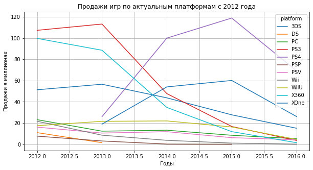

```python
ax = games_sales_actual.plot('year_of_release',figsize=(10,5))
#plt.xticks(rotation = 45) # Rotates X-Axis Ticks by 45-degrees
ylab = ax.set_ylabel('Продажи в миллионах')
xlab = ax.set_xlabel('Годы')
plt.title('Продажи игр по актуальным платформам с 2012 года')
plt.grid()
plt.show()
```

График полностью подтверждает выводы в предыдущем пункте. Самые потенциально прибыльные платформы это PS4 и Xbox One. Теперь построим другой график.

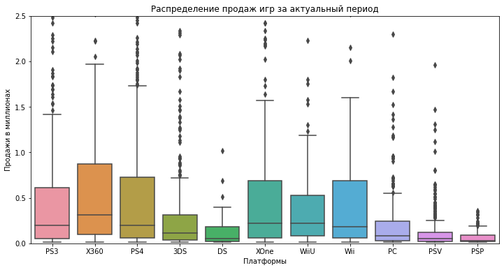

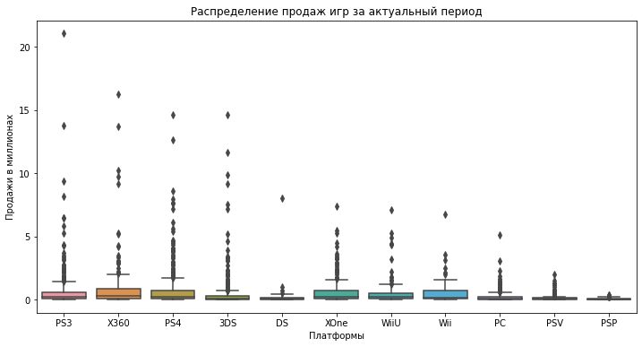

```python
plt.figure(figsize=(12,6))

ax = sns.boxplot(x='platform', y='total_sales', data=games_actual)
ax.set_ylim(0, 2.5)
ax.set_ylabel('Продажи в миллионах')
ax.set_xlabel('Платформы')
ax.set_title('Распределение продаж игр за актуальный период')
plt.show()

plt.figure(figsize=(12,6))
ax = sns.boxplot(x='platform', y='total_sales', data=games_actual)
ax.set_ylabel('Продажи в миллионах')
ax.set_xlabel('Платформы')
ax.set_title('Распределение продаж игр за актуальный период')
plt.show()
```

Предыдуще поколение консолей (PS3, Xbox360, Wii) показывает хорошие продажи но это всё, как мы уже знаем, за счет продаж в закат поколения (в данном случае 2012 и 2013 год) когда выходит много хороших игр, разрабатываемых последние несколько лет на уходящие консоли а новые еще не вышли. Я рекомендую делать ставку на новые платфомы, а из них лучше всего смотрятся PS4 и XOne.

```python
top_sales = games_actual.sort_values('total_sales', ascending=False)
display(top_sales.head(15))
```

|  | name | platform | year_of_release | genre | na_sales | eu_sales | jp_sales | other_sales | critic_score | user_score | rating | total_sales |
| --- | --- | --- | --- | --- | --- | --- | --- | --- | --- | --- | --- | --- |
| 16 | Grand Theft Auto V | PS3 | 2013 | Action | 7.02 | 9.09 | 0.98 | 3.96 | 97.0 | 8.2 | M | 21.05 |
| 23 | Grand Theft Auto V | X360 | 2013 | Action | 9.66 | 5.14 | 0.06 | 1.41 | 97.0 | 8.1 | M | 16.27 |
| 31 | Call of Duty: Black Ops 3 | PS4 | 2015 | Shooter | 6.03 | 5.86 | 0.36 | 2.38 | NaN | NaN | no_rating | 14.63 |
| 33 | Pokemon X/Pokemon Y | 3DS | 2013 | Role-Playing | 5.28 | 4.19 | 4.35 | 0.78 | NaN | NaN | no_rating | 14.60 |
| 34 | Call of Duty: Black Ops II | PS3 | 2012 | Shooter | 4.99 | 5.73 | 0.65 | 2.42 | 83.0 | 5.3 | M | 13.79 |
| 35 | Call of Duty: Black Ops II | X360 | 2012 | Shooter | 8.25 | 4.24 | 0.07 | 1.12 | 83.0 | 4.8 | M | 13.68 |
| 42 | Grand Theft Auto V | PS4 | 2014 | Action | 3.96 | 6.31 | 0.38 | 1.97 | 97.0 | 8.3 | M | 12.62 |
| 47 | Pokemon Omega Ruby/Pokemon Alpha Sapphire | 3DS | 2014 | Role-Playing | 4.35 | 3.49 | 3.10 | 0.74 | NaN | NaN | no_rating | 11.68 |
| 60 | Call of Duty: Ghosts | X360 | 2013 | Shooter | 6.73 | 2.56 | 0.04 | 0.91 | 73.0 | 2.6 | M | 10.24 |
| 62 | New Super Mario Bros. 2 | 3DS | 2012 | Platform | 3.66 | 3.14 | 2.47 | 0.63 | 78.0 | 7.2 | E | 9.90 |
| 66 | Halo 4 | X360 | 2012 | Shooter | 6.65 | 2.28 | 0.04 | 0.74 | 87.0 | 7.0 | M | 9.71 |
| 69 | Call of Duty: Ghosts | PS3 | 2013 | Shooter | 4.10 | 3.63 | 0.38 | 1.25 | 71.0 | 2.6 | M | 9.36 |
| 72 | Minecraft | X360 | 2013 | Misc | 5.70 | 2.65 | 0.02 | 0.81 | NaN | NaN | no_rating | 9.18 |
| 73 | Animal Crossing: New Leaf | 3DS | 2012 | Simulation | 2.03 | 2.36 | 4.39 | 0.39 | 88.0 | 8.7 | E | 9.17 |
| 77 | FIFA 16 | PS4 | 2015 | Sports | 1.12 | 6.12 | 0.06 | 1.28 | 82.0 | 4.3 | E | 8.58 |

### Влияние отзывов игроков и критиков

На примере PS4 узнаем как влияют оценки игроков и критиков на продажи игр.

```python
PS4_scores_sales = games_actual.query('platform=="PS4"').loc[:,['total_sales', 'critic_score', 'user_score']]
#PS4_scores_sales.head()
PS4_scores_rus = games_actual.query('platform=="PS4"').loc[:,['total_sales', 'critic_score', 'user_score']]
```

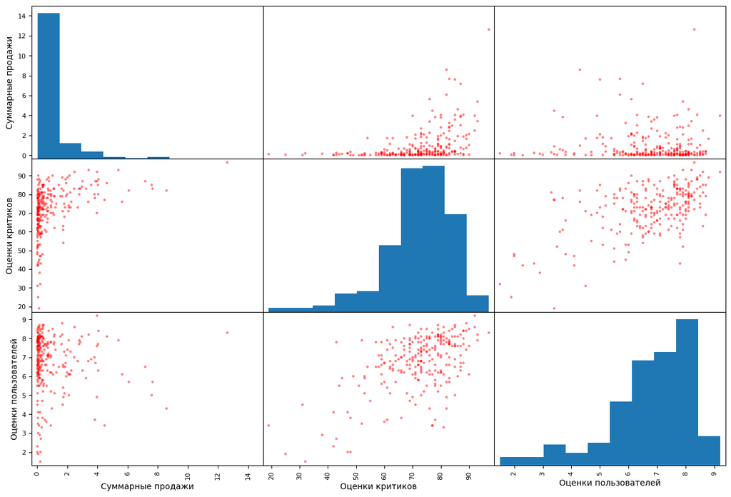

|  | Суммарные продажи | Оценки критиков | Оценки пользователей |
| --- | --- | --- | --- |
| Суммарные продажи | 1.000000 | 0.406568 | -0.031957 |
| Оценки критиков | 0.406568 | 1.000000 | 0.557654 |
| Оценки пользователей | -0.031957 | 0.557654 | 1.000000 |

```python
PS4_scores_rus.rename(columns = {'total_sales':'Суммарные продажи', 'critic_score':'Оценки критиков','user_score':'Оценки пользователей'}, inplace = True)
plt.style.use('default')
pd.plotting.scatter_matrix(PS4_scores_rus, figsize=(15, 10), color='red')
plt.show();
plt.suptitle('Корреляция продаж и оценок PS4')
PS4_scores_rus.corr()
```

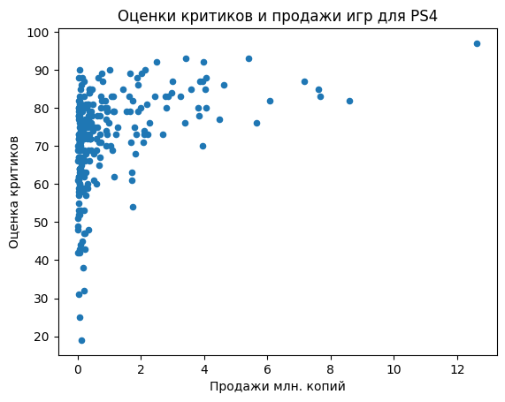

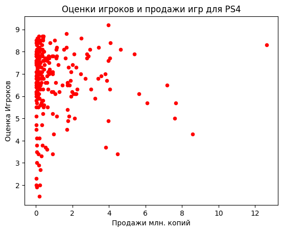

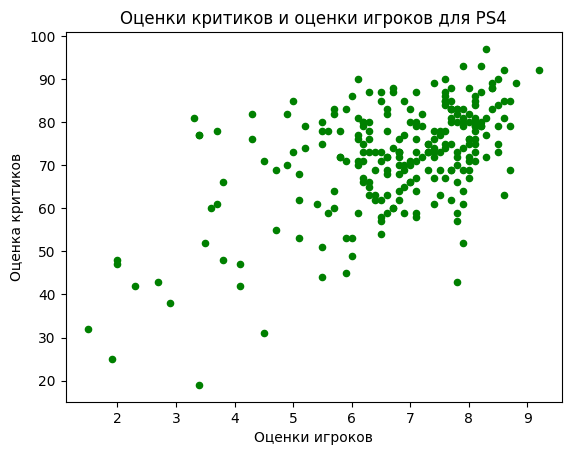

```python
PS4_scores_sales.plot(x='total_sales', y='critic_score', kind='scatter')
plt.ylabel('Оценка критиков')
plt.xlabel('Продажи млн. копий')
plt.title('Оценки критиков и продажи игр для PS4')

PS4_scores_sales.plot(x='total_sales', y='user_score', kind='scatter', color='red')
plt.ylabel('Оценка Игроков')
plt.xlabel('Продажи млн. копий')
plt.title('Оценки игроков и продажи игр для PS4')

PS4_scores_sales.plot(x='user_score', y='critic_score', kind='scatter', color='green')
plt.ylabel('Оценка критиков')
plt.xlabel('Оценки игроков')
plt.title('Оценки критиков и оценки игроков для PS4')
```

Оценки критиков немного коррелируют с продажами игры (40%), в отличии от оценок игроков, которые никак не связанны с продажами. Я бы не удтверждал, что именно оценки критиков сильно влияют на продажи. Как правило, издатели игр дают критикам ознакомиться с игрой до ее официального релиза, поэтому им проще "предугадать" бестселлер и похвалить его, чтобы не портить отношения с издателями, дающими бесплатно оценивать игры до релиза (этим критики и зарабатывают). А вот игроки сначала покупают игру а только потом уже оценивают - их оценка никак не влияет на покупку ведь игра уже куплена, даже если она не понравилась. Так можно объяснить такой большой разброс между оценками игроков и оценками критиков. Проверим эту теорию на других платформах:

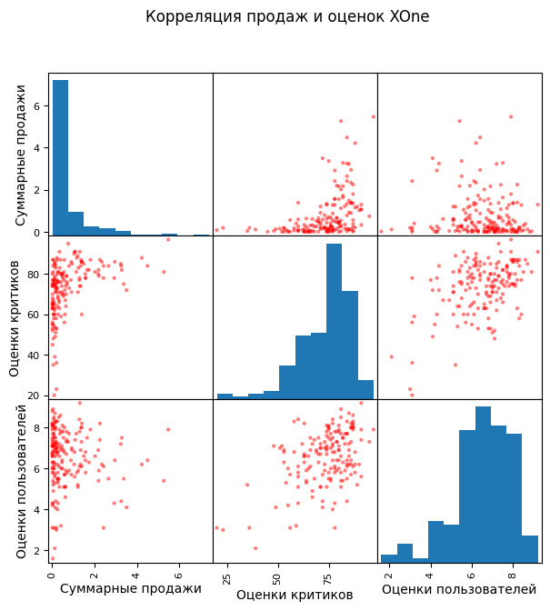

```
Корреляция для XOne
```

|  | Суммарные продажи | Оценки критиков | Оценки пользователей |
| --- | --- | --- | --- |
| Суммарные продажи | 1.000000 | 0.416998 | -0.068925 |
| Оценки критиков | 0.416998 | 1.000000 | 0.472462 |
| Оценки пользователей | -0.068925 | 0.472462 | 1.000000 |

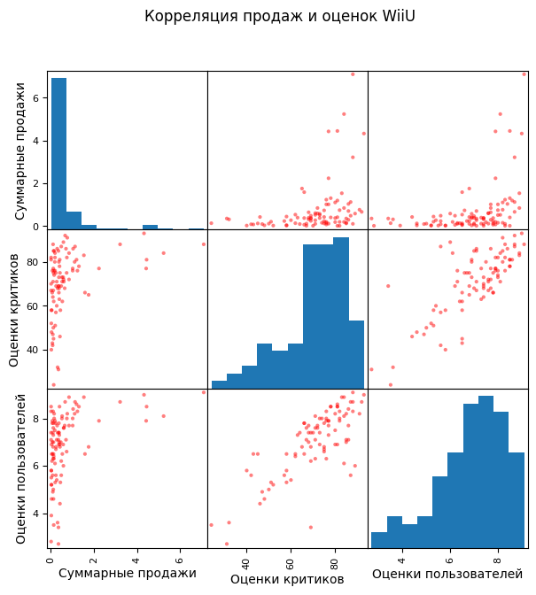

```
Корреляция для WiiU
```

|  | Суммарные продажи | Оценки критиков | Оценки пользователей |
| --- | --- | --- | --- |
| Суммарные продажи | 1.000000 | 0.34838 | 0.400219 |
| Оценки критиков | 0.348380 | 1.00000 | 0.770080 |
| Оценки пользователей | 0.400219 | 0.77008 | 1.000000 |

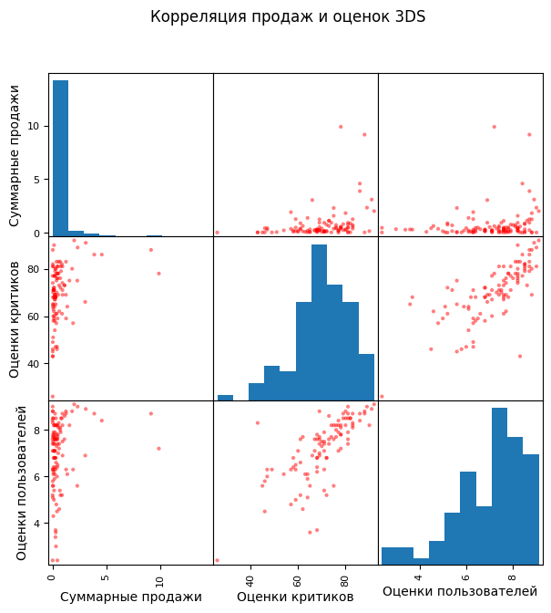

```
Корреляция для 3DS
```

|  | Суммарные продажи | Оценки критиков | Оценки пользователей |
| --- | --- | --- | --- |
| Суммарные продажи | 1.000000 | 0.320803 | 0.197583 |
| Оценки критиков | 0.320803 | 1.000000 | 0.722762 |
| Оценки пользователей | 0.197583 | 0.722762 | 1.000000 |

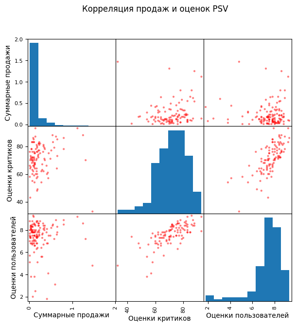

```
Корреляция для PSV
```

|  | Суммарные продажи | Оценки критиков | Оценки пользователей |
| --- | --- | --- | --- |
| Суммарные продажи | 1.000000 | 0.094488 | -0.004339 |
| Оценки критиков | 0.094488 | 1.000000 | 0.699199 |
| Оценки пользователей | -0.004339 | 0.699199 | 1.000000 |

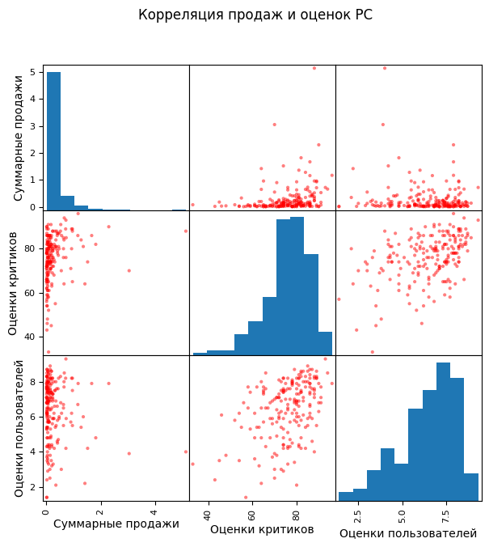

```
Корреляция для PC
```

|  | Суммарные продажи | Оценки критиков | Оценки пользователей |
| --- | --- | --- | --- |
| Суммарные продажи | 1.000000 | 0.237243 | -0.121867 |
| Оценки критиков | 0.237243 | 1.000000 | 0.432587 |
| Оценки пользователей | -0.121867 | 0.432587 | 1.000000 |

```python
platforms = ["XOne", "WiiU", "3DS", "PSV", "PC"]
for platform in platforms:
    sales_matrix = games_actual.query('platform==@platform').loc[:,['total_sales', 'critic_score', 'user_score']]
    sales_matrix.rename(columns = {'total_sales':'Суммарные продажи', 'critic_score':'Оценки критиков','user_score':'Оценки пользователей'}, inplace = True)
    plt.style.use('default')
    pd.plotting.scatter_matrix(sales_matrix, figsize=(7, 7), color='red');
    plt.suptitle('Корреляция продаж и оценок ' + platform)
    plt.show();
    print(f'Корреляция для {platform}')
    display(sales_matrix.corr())
```

Какие наблюдаются отличия у других платформ:

```
============================================================
Расчет по Платформе 3DS
```

```
user_score     0.197583
total_sales    1.000000
Name: total_sales, dtype: float64
```

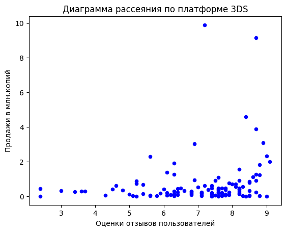

```
critic_score    0.320803
total_sales     1.000000
Name: total_sales, dtype: float64
```

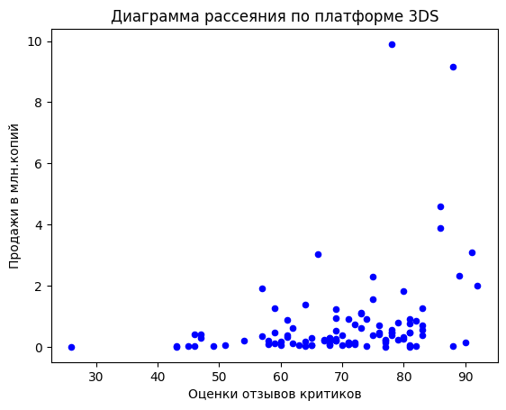

```
============================================================
Расчет по Платформе DS
Для платформы DS не хватает данных для построения диаграммы и расчета корреляции отзывов пользователей
Для платформы DS не хватает данных для построения диаграммы и расчета корреляции отзывов критиков
============================================================
Расчет по Платформе PC
```

```
user_score    -0.121867
total_sales    1.000000
Name: total_sales, dtype: float64
```

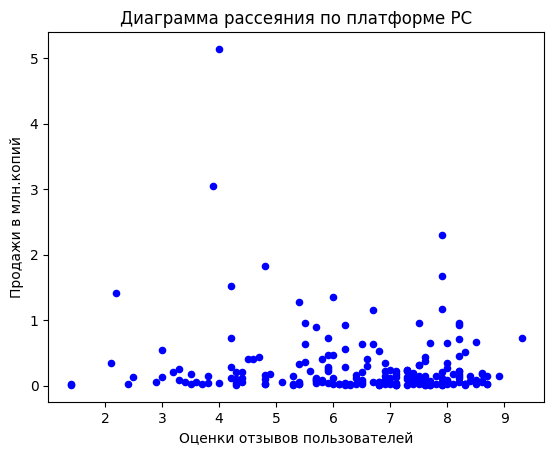

```
critic_score    0.237243
total_sales     1.000000
Name: total_sales, dtype: float64
```

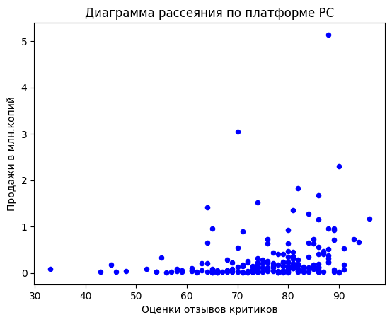

```
============================================================
Расчет по Платформе PS3
```

```
user_score    -0.006206
total_sales    1.000000
Name: total_sales, dtype: float64
```

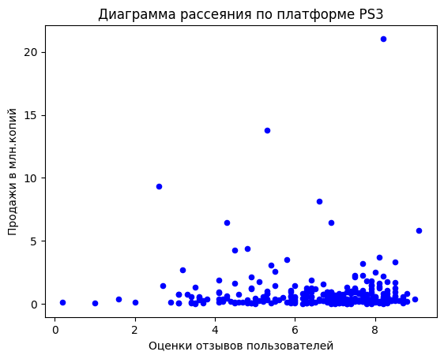

```
critic_score    0.334152
total_sales     1.000000
Name: total_sales, dtype: float64
```

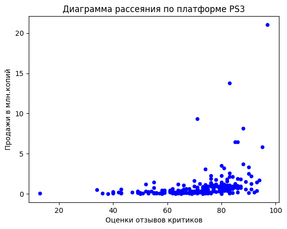

```
============================================================
Расчет по Платформе PS4
```

```
user_score    -0.031957
total_sales    1.000000
Name: total_sales, dtype: float64
```

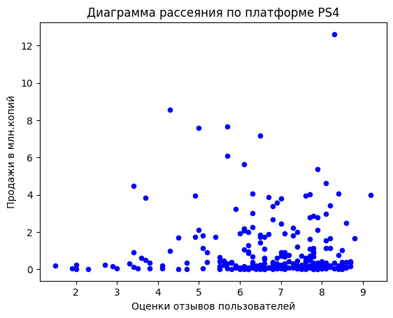

```
critic_score    0.406568
total_sales     1.000000
Name: total_sales, dtype: float64
```

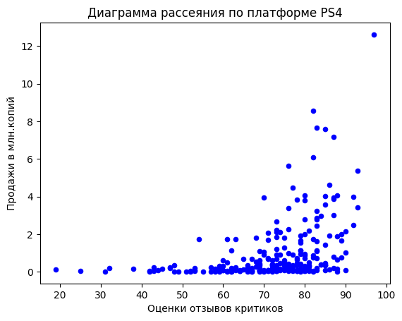

```
============================================================
Расчет по Платформе PSP
```

```
user_score    -0.802302
total_sales    1.000000
Name: total_sales, dtype: float64
```

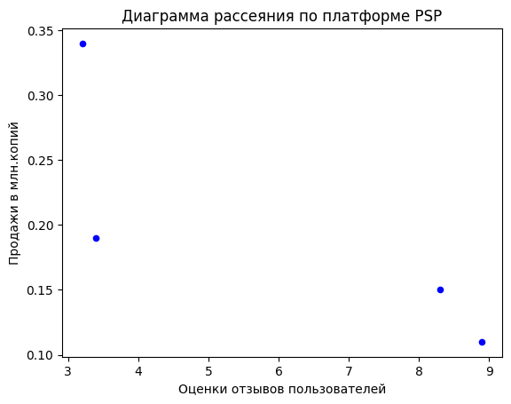

```
Для платформы PSP не хватает данных для построения диаграммы и расчета корреляции отзывов критиков
============================================================
Расчет по Платформе PSV
```

```
user_score    -0.004339
total_sales    1.000000
Name: total_sales, dtype: float64
```

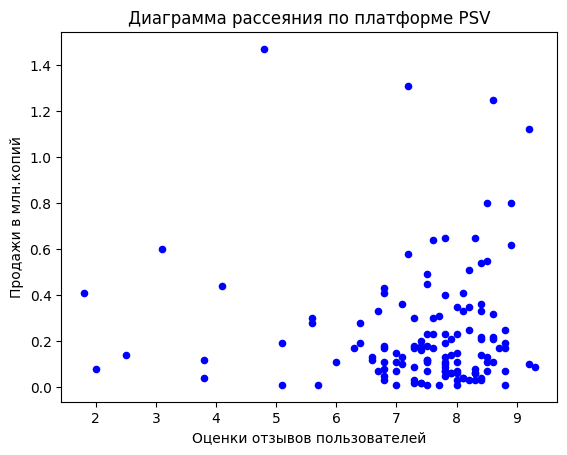

```
critic_score    0.094488
total_sales     1.000000
Name: total_sales, dtype: float64
```

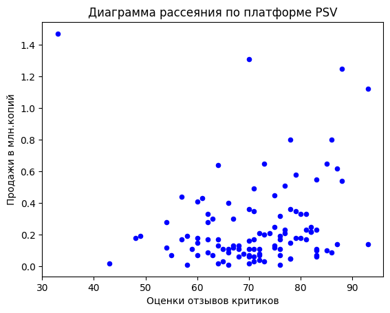

```
============================================================
Расчет по Платформе Wii
```

```
user_score     0.296197
total_sales    1.000000
Name: total_sales, dtype: float64
```

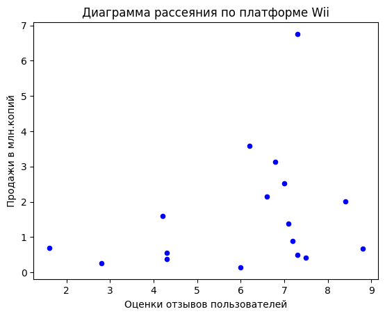

```
critic_score   -0.424341
total_sales     1.000000
Name: total_sales, dtype: float64
```

[7 more figures not shown]

```python
import matplotlib.pyplot as plt
df_sc, y = games_actual.copy(), 'total_sales'
for platform, games_on_pl in df_sc.groupby('platform'):
    print('='*60)
    print('Расчет по Платформе',platform)
    # Считаем сколько в колонке не пустых отзывов
    not_user = len(games_on_pl[games_on_pl['user_score'].notna() == True])
    not_critic = len(games_on_pl[games_on_pl['critic_score'].notna() == True])
    sum_not = 3 # Задаем количество не пустых значений для вывода диаграммы и расчета корреляции
    if not_user > sum_not:
        games_on_pl.plot(kind='scatter', x='user_score', y=y, color='b')
        display(games_on_pl[['user_score', y]].corr()[y])
        plt.xlabel('Оценки отзывов пользователей')
        plt.ylabel('Продажи в млн.копий')
        plt.title('Диаграмма рассеяния по платформе '+platform)
        plt.show()
    else:
        print('Для платформы',platform, 'не хватает данных для построения диаграммы и расчета корреляции отзывов пользователей')
    if not_critic > sum_not:
        games_on_pl.plot(kind='scatter', x='critic_score', y=y, color='b')
        display(games_on_pl[['critic_score', y]].corr()[y])
        plt.xlabel('Оценки отзывов критиков')
        plt.ylabel('Продажи в млн.копий')
        plt.title('Диаграмма рассеяния по платформе '+platform)
        plt.show()
    else:
        print('Для платформы',platform, 'не хватает данных для построения диаграммы и расчета корреляции отзывов критиков')
```

### Распределение по жанрам

Проверим как влияют жанры игр на продажи

```python
temp1, temp2 = games_actual.total_sales.sum(), games[games.year_of_release >= 2012].total_sales.sum()
temp1, temp2, round((temp2-temp1)/temp2*100, 2)
```

```
(1446.5200000000002, 1446.5200000000002, 0.0)
```

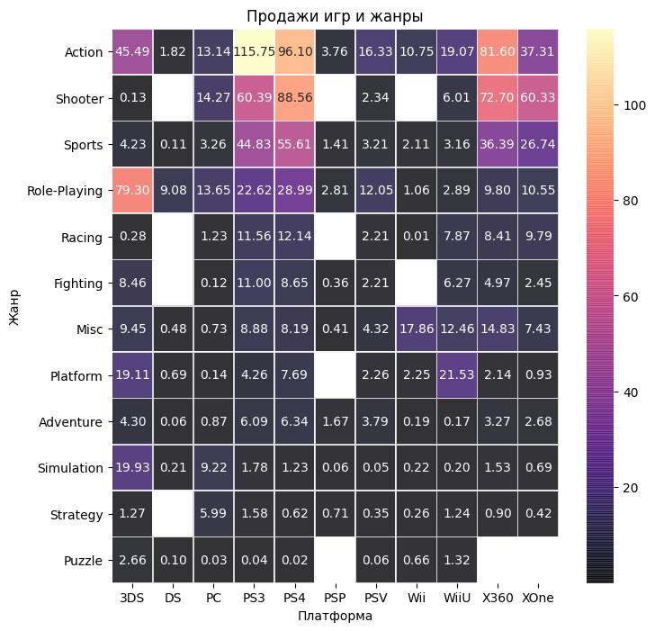

| genre | total_sales |
| --- | --- |
| Action | 441.12 |
| Shooter | 304.73 |
| Role-Playing | 192.80 |
| Sports | 181.06 |
| Misc | 85.04 |
| Platform | 61.00 |
| Racing | 53.50 |
| Fighting | 44.49 |
| Simulation | 35.12 |
| Adventure | 29.43 |
| Strategy | 13.34 |
| Puzzle | 4.89 |

```python
sales_and_genres = games_actual.pivot_table(index='genre', columns='platform', values='total_sales', aggfunc='sum', margins=False).sort_values(by='PS4', ascending=False)
plt.figure(figsize=(8, 8))

sns.heatmap(sales_and_genres, annot=True, linewidths=.5, cmap='magma',fmt = '0.2f', alpha=.8)

plt.title('Продажи игр и жанры')
plt.ylabel('Жанр')
plt.xlabel('Платформа')
plt.show();

display(games_actual.pivot_table(index='genre', values='total_sales', aggfunc='sum').sort_values(by='total_sales', ascending=False))
```

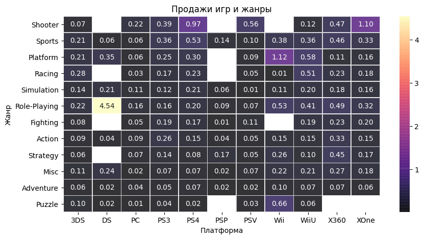

| genre | total_sales |
| --- | --- |
| Shooter | 0.440 |
| Sports | 0.240 |
| Platform | 0.210 |
| Role-Playing | 0.140 |
| Racing | 0.140 |
| Fighting | 0.130 |
| Action | 0.120 |
| Misc | 0.120 |
| Simulation | 0.120 |
| Strategy | 0.080 |
| Puzzle | 0.045 |
| Adventure | 0.030 |

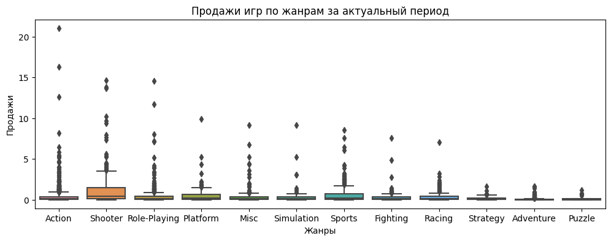

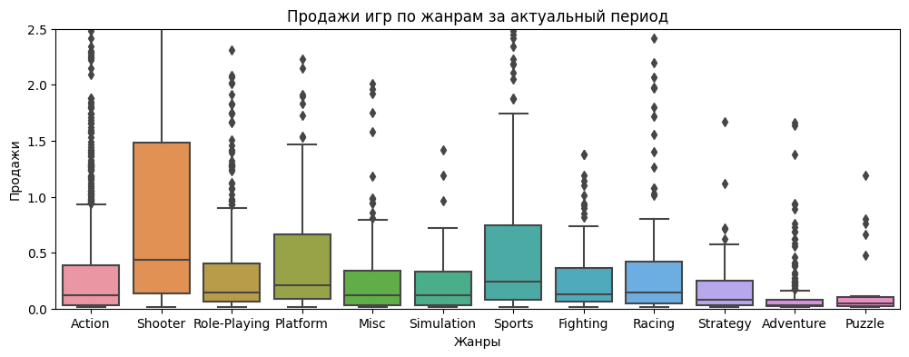

```python
sales_and_genres_median = games_actual.pivot_table(index='genre', columns='platform', values='total_sales', aggfunc='median', margins=False).sort_values(by='PS4', ascending=False)

plt.figure(figsize=(10, 5))
sns.heatmap(sales_and_genres_median, annot=True, linewidths=.5, cmap='magma',fmt = '0.2f', alpha=.8)
plt.title('Продажи игр и жанры')
plt.ylabel('Жанр')
plt.xlabel('Платформа')
plt.show();



display(games_actual.pivot_table(index='genre', values='total_sales', aggfunc='median').sort_values(by='total_sales', ascending=False))

plt.figure(figsize=(12,4))
ax = sns.boxplot(data=games_actual, x='genre', y='total_sales')
ax.set_ylabel('Продажи')
ax.set_xlabel('Жанры')
ax.set_title('Продажи игр по жанрам за актуальный период')
plt.show()

plt.figure(figsize=(12,4))
ax = sns.boxplot(data=games_actual, x='genre', y='total_sales')
ax.set_ylim(0, 2.5)
ax.set_ylabel('Продажи')
ax.set_xlabel('Жанры')
ax.set_title('Продажи игр по жанрам за актуальный период')
plt.show()
```

Если "убрать из уравнения" мастодонтов продаж и посмотреть, какие жанры популярнее всего в целом, то открывается следующая картина:

- Самые непопулярные жанры не меняются
- Шутер - самый выгодный жанр в целом.
- Остальные лидеры суммарных продаж - Ролевые игры и Экшн уступают по медианным продажам Спортивным играм и Платформерам.